# NARW Occurrence GAM Model Testing

# Packages

```r
rm(list = ls())
library(dplyr)
library(lubridate)
# library(scales)

# Visualization
library(ggplot2)
theme_set(theme_light())
library(patchwork)
library(GGally)

# Modeling
library(gamlss)
# library(gamlss.tr)
library(gamlss.add)
library(mgcv)
```

# Load Monthly Data

```r
RWocc0 <- read.csv("RWEnv_monthly.csv")
RWocc <- RWocc0 %>%
    mutate(Date = mdy(Date)) %>%
    mutate(Month = as.numeric(format(Date, "%m")),
           Year = year(Date)) %>%
    # Make sure Date is the 1st of each month, to calculate date differences for lagged values
    mutate(Date = as.Date(paste(Year, Month, "01", sep = "-"))) %>%
    # Add decimal year
    mutate(YearDec = Year + (Month - 0.5) / 12) %>%
    # Change Site, Month, and Period (1 = 2014-17, 2 = 2021-2024) to categorical
    mutate(period = factor(period, levels = c("1", "2")),
           Site = as.factor(Site),
           SongYear = factor(SongYear, levels = paste0("Year", 1:8)),
           MonthFactor = factor(Month, levels = c(11, 12, 1:10)),
           device_type = as.factor(device_type),
           dist_200m_km = as.integer(dist_200m_km)) %>%
    # Create lagged values of PercentOccurrence, by Site
    # Group by period (not SongYear) so lags aren't reset every Nov 1, since months are
    # continuous across SongYear boundaries within a period (only period 1->2 has a real gap)
     arrange(Site, period, Date) %>%
     group_by(Site, period, device_type) %>%
     mutate(gap_days = as.numeric(Date - dplyr::lag(Date)),
            PercentOccurrence_l1 = dplyr::lag(percent_occurrence, 1, order_by = Date),
            PercentOccurrence_l2 = dplyr::lag(percent_occurrence, 2, order_by = Date),
            # invalidate lags that would bridge a real within-period data gap (>31 days)
            PercentOccurrence_l1 = if_else(!is.na(gap_days) & gap_days > 31,
                                           NA_real_,
                                           PercentOccurrence_l1),
            PercentOccurrence_l2 = if_else(dplyr::lag(gap_days, 1) > 31 | gap_days > 31,
                                           NA_real_,
                                           PercentOccurrence_l2)
            ) %>%
     ungroup() %>%
    # Sort by Site and Date
    arrange(Site, Date) |>
    # Create the cold pool index as a categorical factor on monthly level
    mutate(cold_pool_index = if_else(stratification >= 0.2 & bottom_temp <= 10,
                                     "Present",
                                     "Absent") |> factor(levels = c("Absent", "Present"))
    )

# RWocc <- RWocc %>%
#     filter(!SongYear %in% c("Year4", "Year5", "Year8"))

summary(RWocc)
```

```
#>       Date              Site       device_type       sst
#>  Min.   :2014-11-01   A2M :50   Archival :150   Min.   : 2.371
#>  1st Qu.:2016-02-22   A7M :50   Real Time: 42   1st Qu.: 9.272
#>  Median :2017-06-16   RTWB:42                   Median :14.951
#>  Mean   :2019-04-23   T2M :50                   Mean   :15.351
#>  3rd Qu.:2023-06-01                             3rd Qu.:20.805
#>  Max.   :2024-12-01                             Max.   :26.935
#>
#>   bottom_temp          sss        stratification         phase
#>  Min.   : 2.793   Min.   :29.43   Min.   :-0.03835   Min.   :0.2518
#>  1st Qu.: 8.581   1st Qu.:31.50   1st Qu.:-0.00650   1st Qu.:0.4829
#>  Median :11.808   Median :32.06   Median : 0.03544   Median :0.5010
#>  Mean   :12.104   Mean   :32.11   Mean   : 0.09833   Mean   :0.4979
#>  3rd Qu.:15.617   3rd Qu.:32.67   3rd Qu.: 0.18866   3rd Qu.:0.5129
#>  Max.   :21.330   Max.   :33.76   Max.   : 0.42819   Max.   :0.8927
#>
#>  daylight_hours      sstAnom             site           days_monitored
#>  Min.   : 9.534   Min.   :-2.66194   Length:192         Min.   : 5.00
#>  1st Qu.:10.198   1st Qu.: 0.04285   Class :character   1st Qu.:30.00
#>  Median :12.031   Median : 0.83932   Mode  :character   Median :31.00
#>  Mean   :12.182   Mean   : 0.68095                      Mean   :29.07
#>  3rd Qu.:13.894   3rd Qu.: 1.23426                      3rd Qu.:31.00
#>  Max.   :14.796   Max.   : 3.19913                      Max.   :31.00
#>
#>   days_present    percent_occurrence period   dist_200m_km      SongYear
#>  Min.   : 0.000   Min.   : 0.000     1:111   Min.   :55.00   Year1  :36
#>  1st Qu.: 0.000   1st Qu.: 0.000     2: 81   1st Qu.:55.00   Year2  :36
#>  Median : 1.000   Median : 3.333             Median :67.00   Year3  :36
#>  Mean   : 4.354   Mean   :14.488             Mean   :68.04   Year6  :33
#>  3rd Qu.: 8.000   3rd Qu.:27.586             3rd Qu.:83.00   Year7  :28
#>  Max.   :29.000   Max.   :93.548             Max.   :83.00   Year5  :18
#>                                                              (Other): 5
#>      Month             Year         YearDec      MonthFactor    gap_days
#>  Min.   : 1.000   Min.   :2014   Min.   :2015   11     :19   Min.   :28.00
#>  1st Qu.: 4.000   1st Qu.:2016   1st Qu.:2016   4      :18   1st Qu.:30.00
#>  Median : 7.000   Median :2017   Median :2018   12     :16   Median :31.00
#>  Mean   : 6.594   Mean   :2019   Mean   :2019   5      :16   Mean   :30.79
#>  3rd Qu.:10.000   3rd Qu.:2023   3rd Qu.:2023   6      :16   3rd Qu.:31.00
#>  Max.   :12.000   Max.   :2024   Max.   :2025   7      :16   Max.   :92.00
#>                                                 (Other):91   NA's   :7
#>  PercentOccurrence_l1 PercentOccurrence_l2 cold_pool_index
#>  Min.   : 0.000       Min.   : 0.00        Absent :191
#>  1st Qu.: 0.000       1st Qu.: 0.00        Present:  1
#>  Median : 3.333       Median : 3.28
#>  Mean   :14.661       Mean   :14.70
#>  3rd Qu.:27.586       3rd Qu.:27.59
#>  Max.   :93.548       Max.   :93.55
#>  NA's   :8            NA's   :16
```

```r
# Subset without non-missing data (due to lags), if needed for modeling
RWocc_noNA <- na.omit(RWocc)
```

```r
# Sample sizes for different combinations
table(RWocc$Year, RWocc$Site)
```

```
#>
#>        A2M A7M RTWB T2M
#>   2014   2   2    0   2
#>   2015  12  12    0  12
#>   2016  12  12    0  12
#>   2017  11  11    0  11
#>   2021   0   0    8   0
#>   2022   0   0   12   0
#>   2023   9   9   12   9
#>   2024   4   4   10   4
```

```r
table(RWocc$SongYear, RWocc$Site) # Song Year5 started early
```

```
#>
#>         A2M A7M RTWB T2M
#>   Year1  12  12    0  12
#>   Year2  12  12    0  12
#>   Year3  12  12    0  12
#>   Year4   1   1    0   1
#>   Year5   0   0   18   0
#>   Year6   7   7   12   7
#>   Year7   6   6   10   6
#>   Year8   0   0    2   0
```

```r
# RWocc |>
#   dplyr::filter(Site == "RTWB", SongYear == "Year5") |>
#   dplyr::select(Date, device_type, percent_occurrence)
table(RWocc$device_type, RWocc$period)
```

```
#>
#>               1   2
#>   Archival  111  39
#>   Real Time   0  42
```

```r
table(RWocc$period, RWocc$Year)
```

```
#>
#>     2014 2015 2016 2017 2021 2022 2023 2024
#>   1    6   36   36   33    0    0    0    0
#>   2    0    0    0    0    8   12   39   22
```

## Exploring the data on the monthly scale

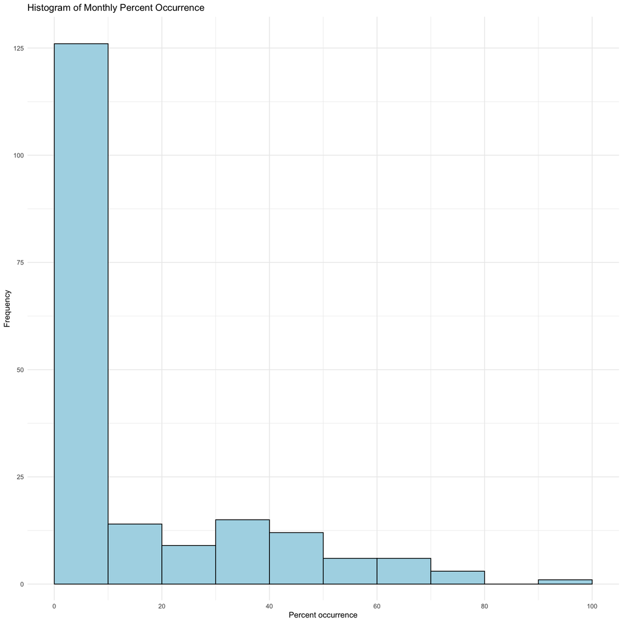

```r
# Histogram of response variable - monthly
ggplot(RWocc, aes(x = percent_occurrence)) +
  geom_histogram(binwidth = 10, boundary = 0, fill = "lightblue", color = "black") +
  scale_x_continuous(limits = c(0, 100), breaks = seq(0, 100, 20)) +
  scale_y_continuous(expand = expansion(mult = c(0.03, 0.05))) +
  labs(title = "Histogram of Monthly Percent Occurrence",
       x = "Percent occurrence",
       y = "Frequency") +
  theme_minimal()
```

Count of zeros and proportion of zeros

```r
c(sum(RWocc$percent_occurrence == 0),
  mean(RWocc$percent_occurrence == 0))
```

```
#> [1] 86.0000000  0.4479167
```

Based on the histogram and the proportion of zeros, it appears that the monthly percent occurrence data is highly skewed with a significant number of zero values. This suggests that a zero inflated distribution might be appropriate.

```r
# MONTHLY

# subset of data only environmental variables + percent occurrence
monthenv_vars <- RWocc[, c("Date", "SongYear", "Site", "sst", "bottom_temp",
                           "sss", "stratification", "sstAnom",
                           "phase", "device_type", "Month", "period", "daylight_hours",
                           "cold_pool_index", "dist_200m_km", "percent_occurrence")]

# ggpairs(monthenv_vars,
#         title = "Monthly Pairwise Correlations",
#         #mapping = aes(color = Site, alpha = 0.7),
#         upper = list(continuous = wrap("cor", size = 4.5)),
#         #lower = list(continuous = wrap("points", alpha = 0.6, size = 0.5)),
#         lower = list(combo = wrap("facethist", binwidth = 0.5))) +
#   theme_minimal()
```

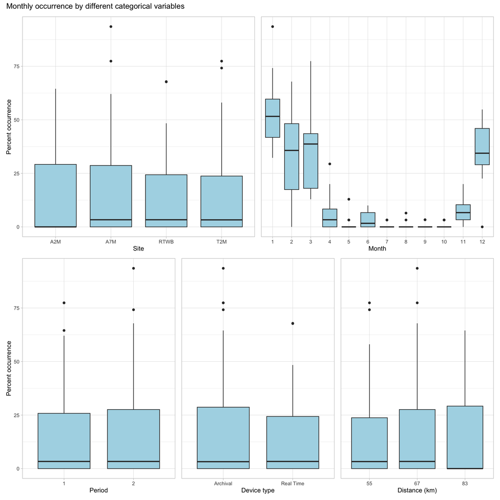

```r
# Boxplots of Occurrence by different categorical variables
p1 <- ggplot(RWocc, aes(x = Site, y = percent_occurrence)) +
  geom_boxplot(fill = "lightblue") +
  ylab("Percent occurrence")
p2 <- ggplot(RWocc, aes(x = as.factor(Month), y = percent_occurrence)) +
  geom_boxplot(fill = "lightblue") +
  labs(x = "Month", y = "Percent occurrence")
p3 <- ggplot(RWocc, aes(x = period, y = percent_occurrence)) +
  geom_boxplot(fill = "lightblue") +
  labs(x = "Period", y = "Percent occurrence")
p4 <- ggplot(RWocc, aes(x = device_type, y = percent_occurrence)) +
  geom_boxplot(fill = "lightblue") +
  labs(x = "Device type", y = "Percent occurrence")
p5 <- ggplot(RWocc, aes(x = as.factor(dist_200m_km), y = percent_occurrence)) +
  geom_boxplot(fill = "lightblue") +
  labs(x = "Distance (km)", y = "Percent occurrence")

# Combine with patchwork
row1 <- (p1 + p2) + plot_layout(axes = "collect_y", axis_titles = "collect_y")
row2 <- (p3 + p4 + p5) + plot_layout(axes = "collect_y", axis_titles = "collect_y")
row1 / row2 +
  plot_annotation(title = "Monthly occurrence by different categorical variables")
```

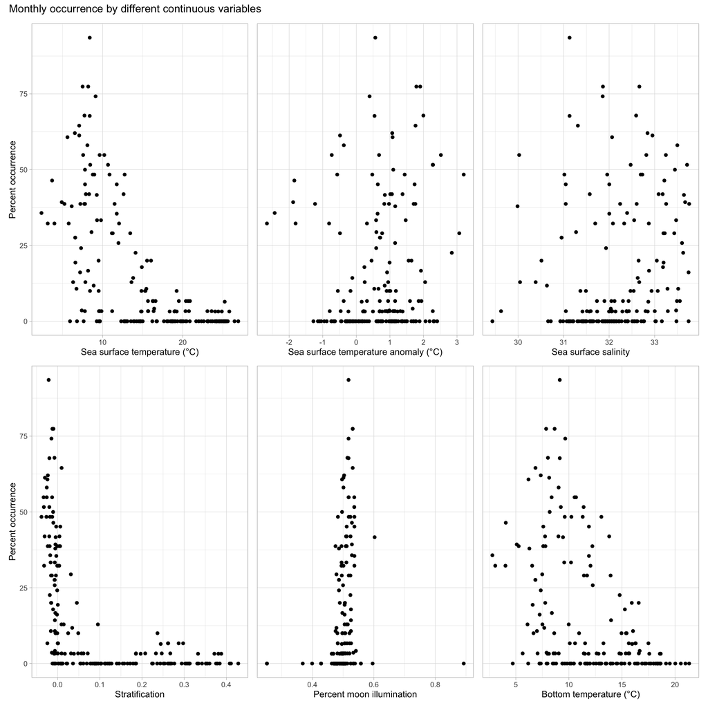

```r
# Scatter plots for continuous variables
c1 <- ggplot(RWocc, aes(y = percent_occurrence, x = sst)) + geom_point() +
  labs(x = "Sea surface temperature (°C)", y = "Percent occurrence")
c11 <- ggplot(RWocc, aes(y = percent_occurrence, x = sstAnom)) + geom_point() +
  labs(x = "Sea surface temperature anomaly (°C)", y = "Percent occurrence")
c2 <- ggplot(RWocc, aes(y = percent_occurrence, x = sss)) + geom_point() +
  labs(x = "Sea surface salinity", y = "Percent occurrence")
c3 <- ggplot(RWocc, aes(y = percent_occurrence, x = stratification)) + geom_point() +
  labs(x = "Stratification", y = "Percent occurrence")
c4 <- ggplot(RWocc, aes(y = percent_occurrence, x = phase)) + geom_point() +
  labs(x = "Percent moon illumination", y = "Percent occurrence")
c5 <- ggplot(RWocc, aes(y = percent_occurrence, x = bottom_temp)) + geom_point() +
  labs(x = "Bottom temperature (°C)", y = "Percent occurrence")

# Combine with patchwork
row1 <- (c1 + c11 + c2) + plot_layout(axes = "collect_y", axis_titles = "collect_y")
row2 <- (c3 + c4 + c5) + plot_layout(axes = "collect_y", axis_titles = "collect_y")
row1 / row2 +
  plot_annotation(title = "Monthly occurrence by different continuous variables")
```

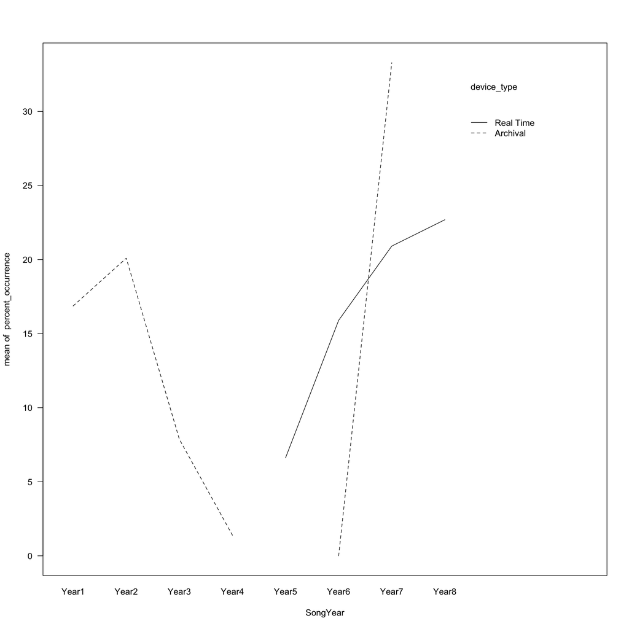

```r
# Interaction plot
with(RWocc,
     interaction.plot(SongYear, device_type, percent_occurrence,
                      las = 1)
)
```

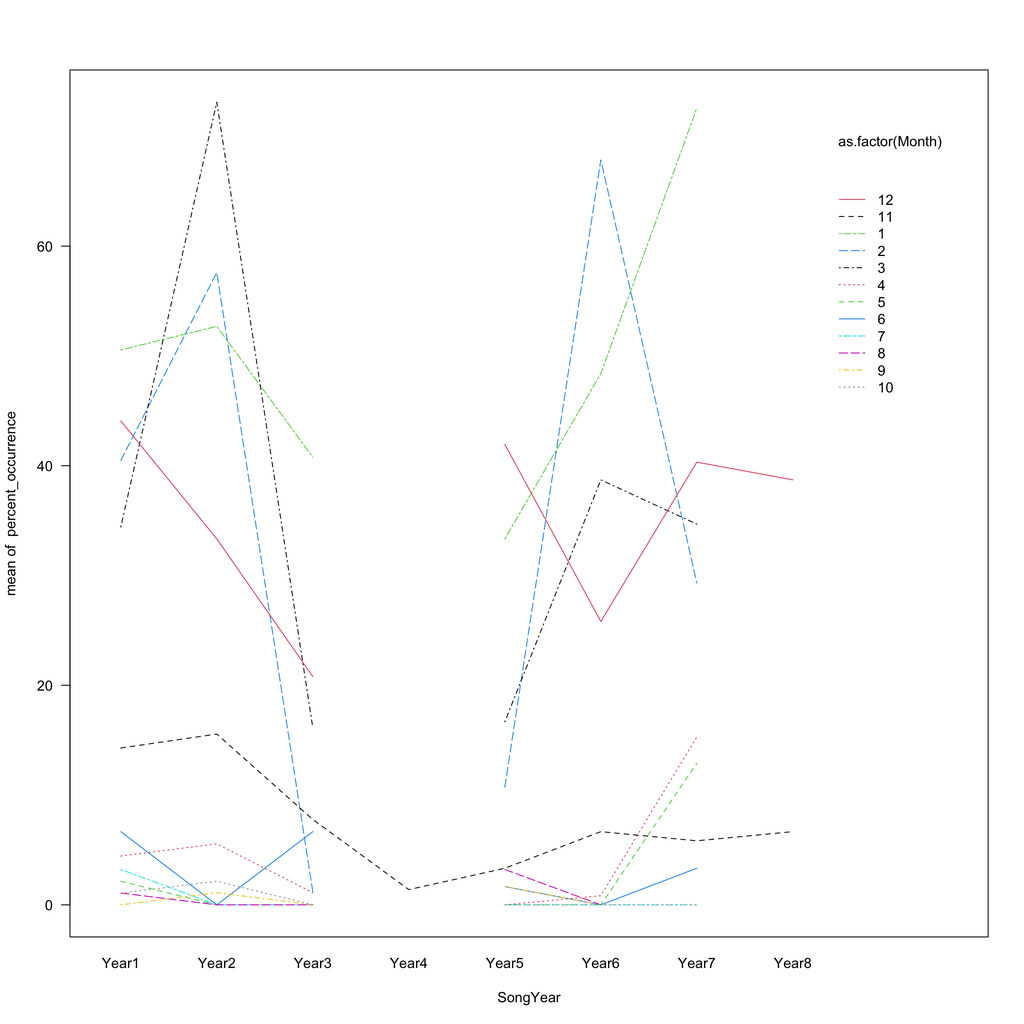

```r
with(RWocc,
     interaction.plot(SongYear, as.factor(Month), percent_occurrence,
                      las = 1, col = as.factor(Month))
)
```

Time series plots per site

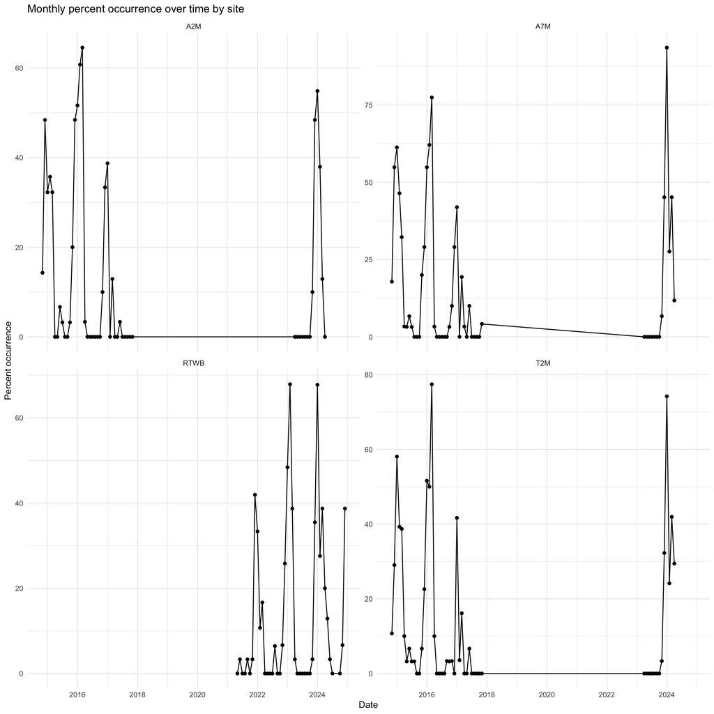

```r
ggplot(RWocc, aes(x = Date, y = percent_occurrence,
                  group = Site)) +
  geom_line() +
  geom_point() +
  labs(title = "Monthly percent occurrence over time by site",
       x = "Date",
       y = "Percent occurrence") +
  theme_minimal() +
  facet_wrap(~ Site, scales = "free_y")
```

Time series plots per site and **calendar year** (note small samples in Year 2014 and 2024)

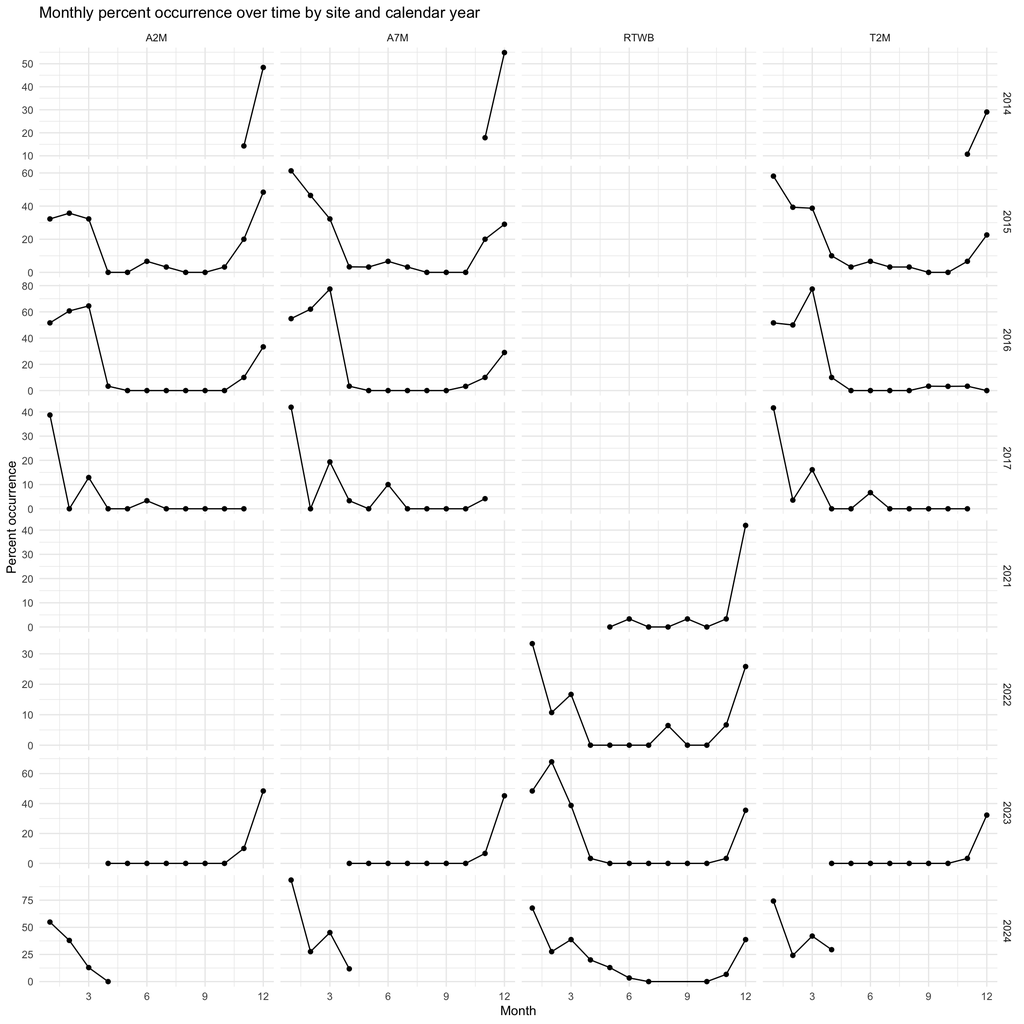

```r
ggplot(RWocc, aes(x = Month, y = percent_occurrence,
                  group = Site)) +
  geom_line() +
  geom_point() +
  scale_x_continuous(breaks = seq(3, 12, by = 3)) +
  labs(title = "Monthly percent occurrence over time by site and calendar year",
       x = "Month",
       y = "Percent occurrence") +
  theme_minimal() +
  facet_grid(Year ~ Site, scales = "free_y")
```

Time series plots per site and **song year** (note small samples in Year4 and Year8; repeated months in Year5)

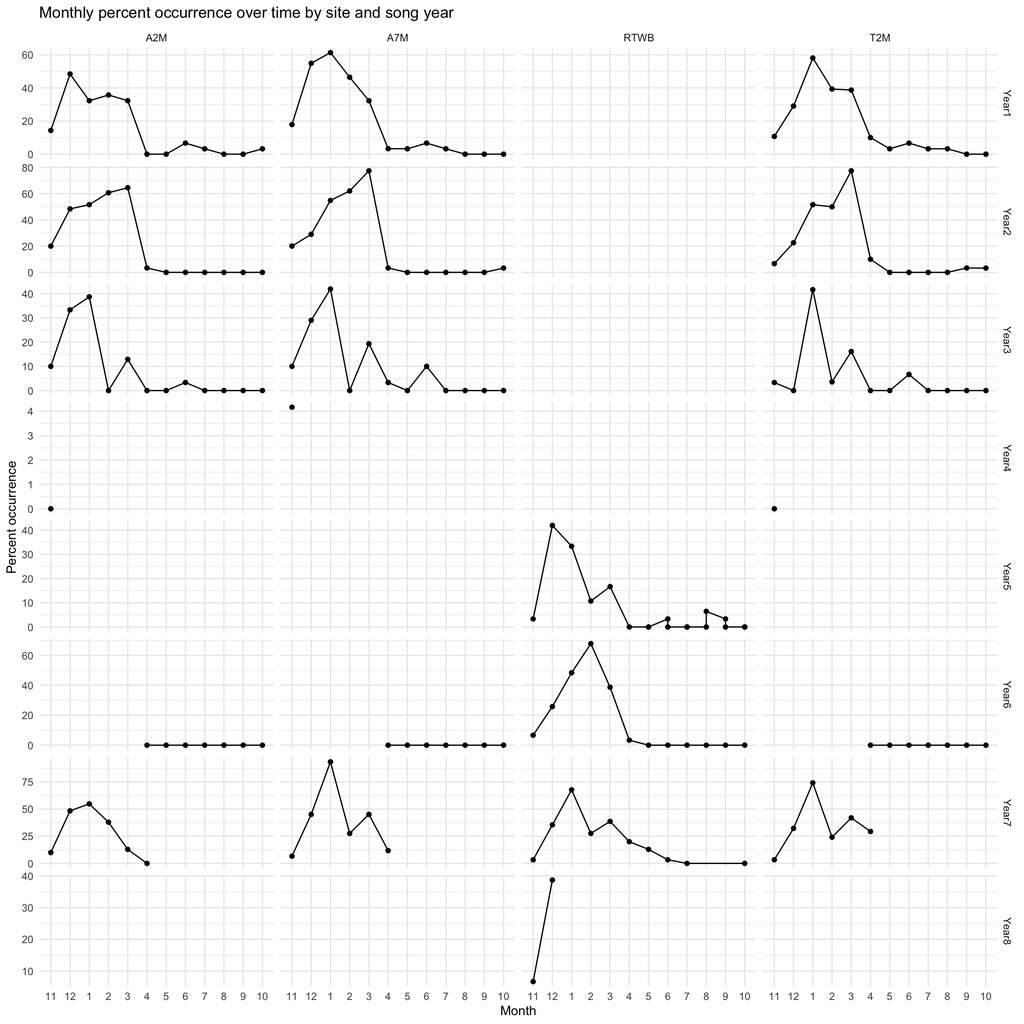

```r
ggplot(RWocc, aes(x = MonthFactor, y = percent_occurrence,
                  group = Site)) +
  geom_line() +
  geom_point() +
  labs(title = "Monthly percent occurrence over time by site and song year",
       x = "Month",
       y = "Percent occurrence") +
  theme_minimal() +
  facet_grid(SongYear ~ Site, scales = "free_y")
```

## Model from NARWC 2025

```r
# Modeling ---- model used in NARW consortium 2025 presentation -- monthly % occ -- year continuous
set.seed(123)
m_RWocc0 <- gamlss(percent_occurrence / 100 ~
                    #  ga(~ti(year, Month)) +
                      scs(Month, control = cs.control(cv = FALSE)) +
                    #   scs(sst, control = cs.control(cv = FALSE)) +
                      # pb(sst) +
                      # pb(sss) +
                      # pb(phase) +
                      # ga(~s(Month, bs = "cp")) +
                    #  pb(year) +
                       pb(Year) +
                      device_type +
                      Site
                  # + pvc(Month, by = Site)
                  # ,sigma.formula = ~pb(Month) #+ pb(Year)
                  ,family = BEINF, #beta inflated
                  control = gamlss.control(c.crit = 0.01, n.cyc = 100, trace = FALSE),
                  data = RWocc |> dplyr::select(-dplyr::any_of(c("gap_days",
                                                                  "PercentOccurrence_l1",
                                                                  "PercentOccurrence_l2"))))
summary(m_RWocc0)
```

```
#> Family:  c("BEINF", "Beta Inflated")
#>
#> Call:
#> gamlss(formula = percent_occurrence/100 ~ scs(Month, control = cs.control(cv = FALSE)) +
#>     pb(Year) + device_type + Site, family = BEINF, data = dplyr::select(RWocc,
#>     -dplyr::any_of(c("gap_days", "PercentOccurrence_l1", "PercentOccurrence_l2"))),
#>     control = gamlss.control(c.crit = 0.01, n.cyc = 100, trace = FALSE))
#>
#> Fitting method: RS()
#>
#> ------------------------------------------------------------------
#> Mu link function:  logit
#> Mu Coefficients:
#>                                                Estimate Std. Error t value
#> (Intercept)                                  -5.116e+01  3.592e+01  -1.424
#> scs(Month, control = cs.control(cv = FALSE)) -1.250e-01  1.310e-02  -9.542
#> pb(Year)                                      2.510e-02  1.780e-02   1.410
#> device_typeReal Time                          1.697e-02  1.921e-01   0.088
#> SiteA7M                                       2.646e-01  1.563e-01   1.693
#> SiteT2M                                      -2.997e-04  1.587e-01  -0.002
#>                                              Pr(>|t|)
#> (Intercept)                                    0.1561
#> scs(Month, control = cs.control(cv = FALSE))   <2e-16 ***
#> pb(Year)                                       0.1603
#> device_typeReal Time                           0.9297
#> SiteA7M                                        0.0923 .
#> SiteT2M                                        0.9985
#> ---
#> Signif. codes:  0 '***' 0.001 '**' 0.01 '*' 0.05 '.' 0.1 ' ' 1
#>
#> ------------------------------------------------------------------
#> Sigma link function:  logit
#> Sigma Coefficients:
#>             Estimate Std. Error t value Pr(>|t|)
#> (Intercept) -1.14026    0.07968  -14.31   <2e-16 ***
#> ---
#> Signif. codes:  0 '***' 0.001 '**' 0.01 '*' 0.05 '.' 0.1 ' ' 1
#>
#> ------------------------------------------------------------------
#> Nu link function:  log
```

[output cut: 8 more lines]

```
#> (Intercept)   -19.42     971.93   -0.02    0.984
#>
#> ------------------------------------------------------------------
#> NOTE: Additive smoothing terms exist in the formulas:
#>  i) Std. Error for smoothers are for the linear effect only.
#> ii) Std. Error for the linear terms may not be reliable.
#> ------------------------------------------------------------------
#> No. of observations in the fit:  192
#> Degrees of Freedom for the fit:  22.17666
#>       Residual Deg. of Freedom:  169.8233
#>                       at cycle:  7
#>
#> Global Deviance:     30.87573
#>             AIC:     75.22905
#>             SBC:     147.4694
```

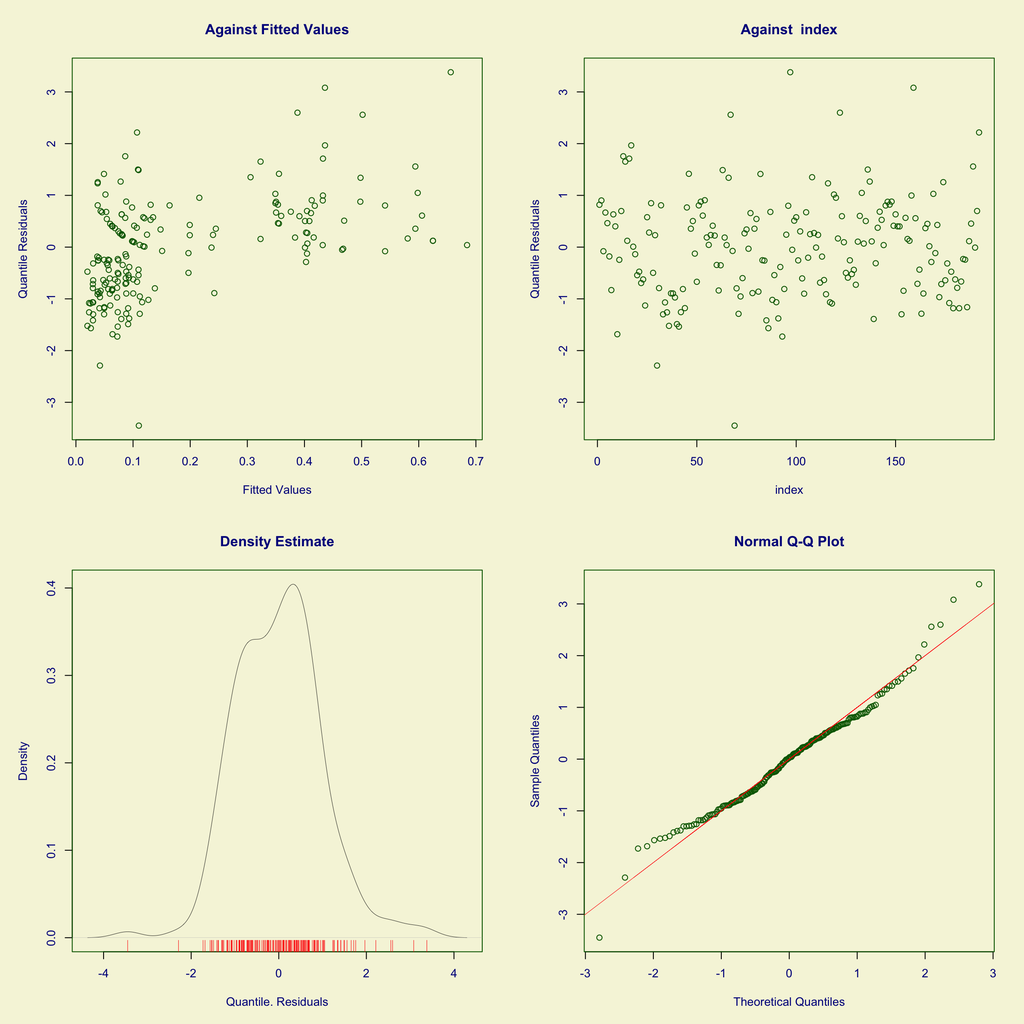

```
#>   Summary of the Randomised Quantile Residuals
#>                            mean   =  -0.002284521
#>                        variance   =  0.9474518
#>                coef. of skewness  =  0.2923899
#>                coef. of kurtosis  =  4.025169
#> Filliben correlation coefficient  =  0.9895405
```

```r
# year as categorical can test with anova likelihood ratio test, does make sense to use as categorical with missing 2018-2020 period rather than with smooth on continuous year.

## Model diagnostics ----
plot(m_RWocc0)
```

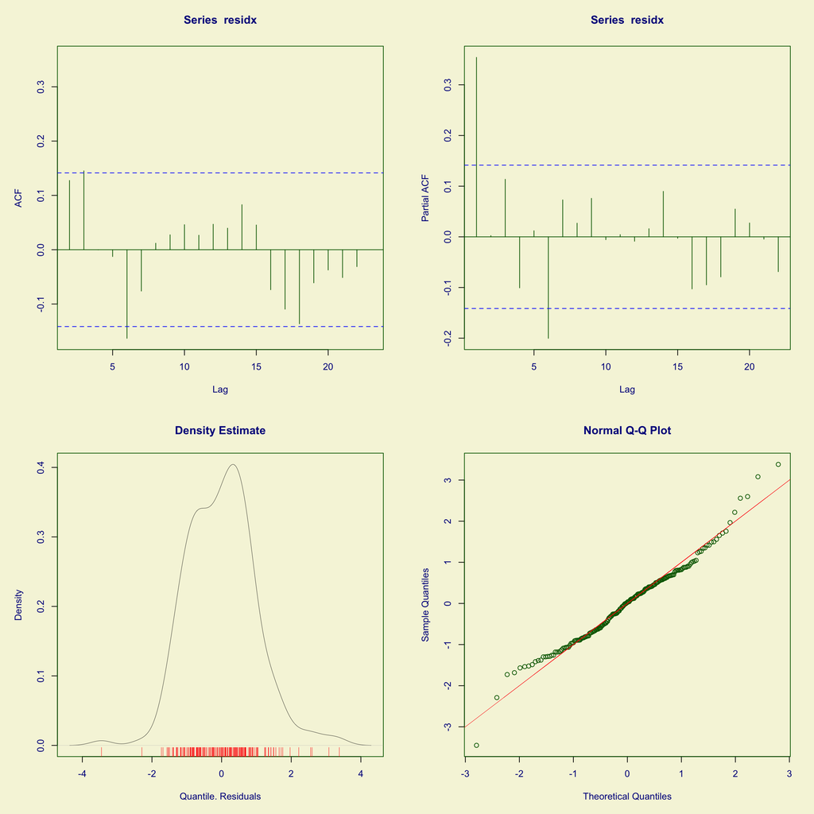

```
#>   Summary of the Randomised Quantile Residuals
#>                            mean   =  -0.002284521
#>                        variance   =  0.9474518
#>                coef. of skewness  =  0.2923899
#>                coef. of kurtosis  =  4.025169
#> Filliben correlation coefficient  =  0.9895405
```

```r
plot(m_RWocc0, ts = TRUE)
```

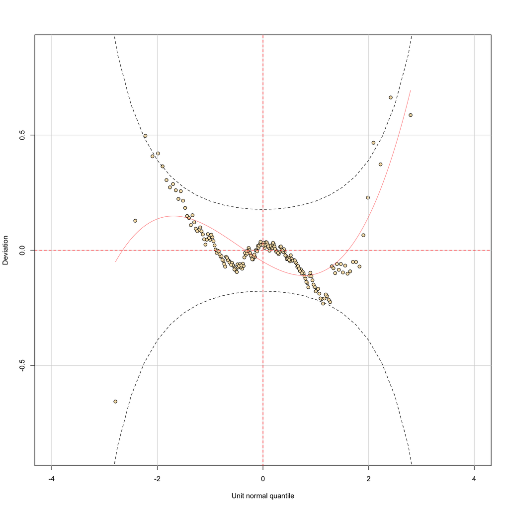

```r
wp(m_RWocc0)
```

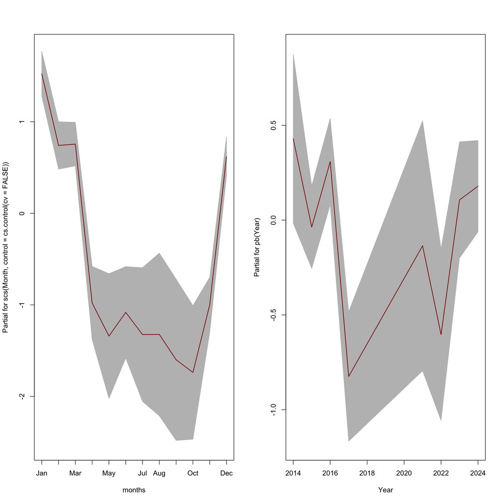

```r
# Term plots of month and year
par(mfrow = c(1, 2))

# --- PANEL 1: Month (Custom Axis) ---
# We use terms = 1 to target the first smooth term (Month)
term.plot(m_RWocc0, terms = 1, xaxt = "n", xlab = "months")

# Define and add your custom text labels
axis(side = 1, at = 1:12, labels = month.abb)

# --- PANEL 2: Year (Default Axis) ---
# We use terms = 2 to target the second smooth term (Year)
term.plot(m_RWocc0, terms = 2, xlab = "Year")
```